# SI 544 Day 2: Visualization

Matthew Garvin (mgarvin)

9/11/2020

## Day 2: Libraries

Before we get started, let’s load the libraries that we’ll need for today:

```r
library(nycflights13)
library(ggplot2)
library(dplyr)
library(gapminder)
library(knitr)
library(readr)
library(tidyverse)
```

## Gapminder

```r
gapminder_2007 <- gapminder %>%
  filter(year == 2007) %>%
  select(-year) %>%
  rename(
    Country = country,
    Continent = continent,
    `Life Expectancy` = lifeExp,
    `Population` = pop,
    `GDP per Capita` = gdpPercap
  )
```

You might want to View(gapminder_2007) in the Console.

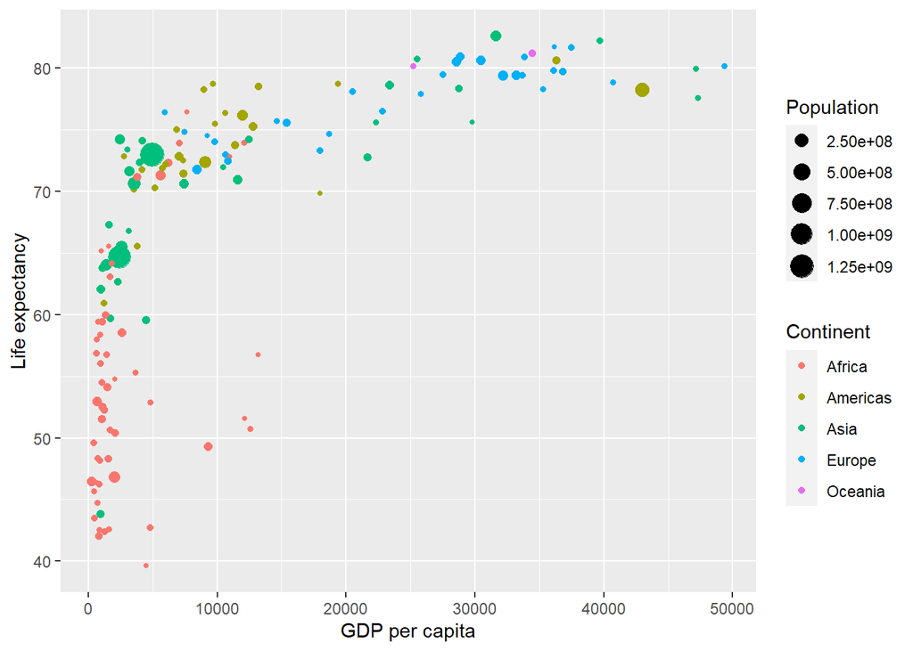

```r
ggplot(data = gapminder_2007,
       mapping = aes(x = `GDP per Capita`,
                     y = `Life Expectancy`,
                     size = Population,
                     color = Continent)) +
  geom_point() +
  labs(x = "GDP per capita", y = "Life expectancy")
```

## Scatterplots

```r
alaska_flights <- flights %>%
  filter(carrier == "AS")
```

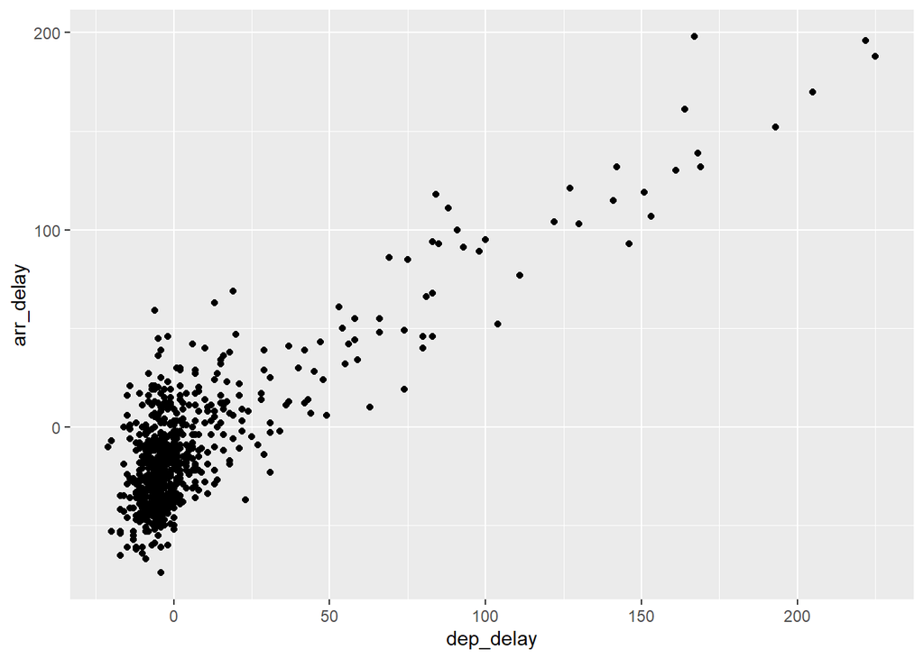

```r
ggplot(data = alaska_flights, mapping = aes(x = dep_delay, y = arr_delay)) +
  geom_point()
```

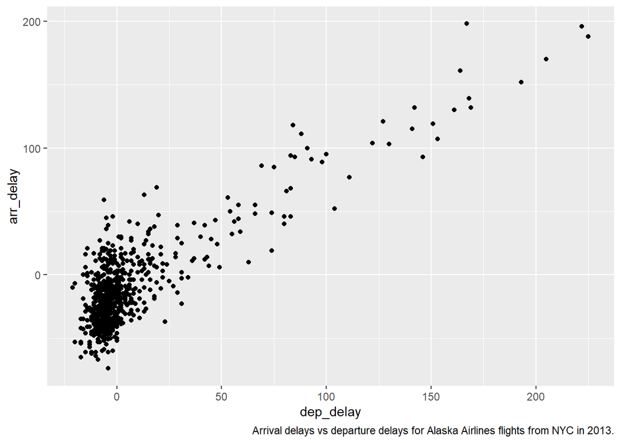

```r
ggplot(data = alaska_flights, mapping = aes(x = dep_delay, y = arr_delay)) +
  geom_point() +
  labs(caption="Arrival delays vs departure delays for Alaska Airlines flights from NYC in 2013.")
```

## Learning Check (LC3.2)

What are some practical reasons why dep_delay and arr_delay have a positive relationship?

INSERT YOUR ANSWER HERE If a flight has a departure delay, it is likely to have an arrival delay as well.

## Learning Check (LC3.5)

What are some other features of the plot that stand out to you?

INSERT YOUR ANSWER HERE What stands out to me more is the lack of features. Is the delay in minutes? That’s not clear. But I notice the caption and that is helpful compared to the previous plot.

Overplotting

If you don’t create a geom layer, you don’t get much:

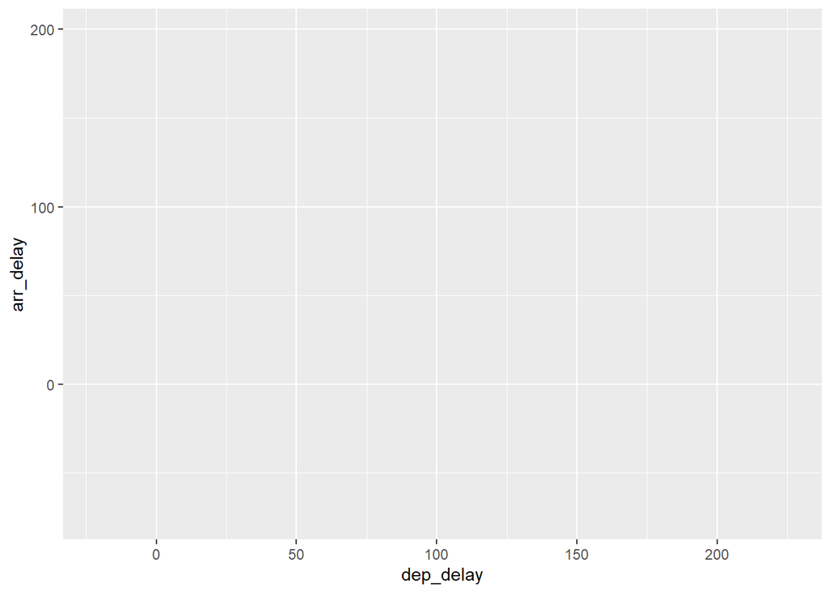

```r
ggplot(data = alaska_flights, mapping = aes(x = dep_delay, y = arr_delay))
```

## Addressing Overplotting

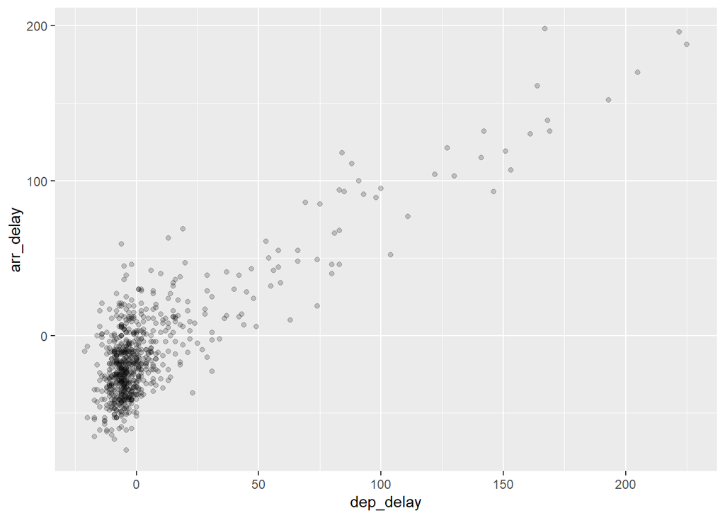

```r
ggplot(data = alaska_flights, mapping = aes(x = dep_delay, y = arr_delay)) +
  geom_point(alpha = 0.2)
```

Let’s look at jitter (and introduce tibbles at the same time):

```r
jitter_example <- tibble(
  x = c(0, 0, 0, 0),
  y = c(0, 0, 0, 0)
)
jitter_example
```

```
## # A tibble: 4 x 2
##       x     y
##   <dbl> <dbl>
## 1     0     0
## 2     0     0
## 3     0     0
## 4     0     0
```

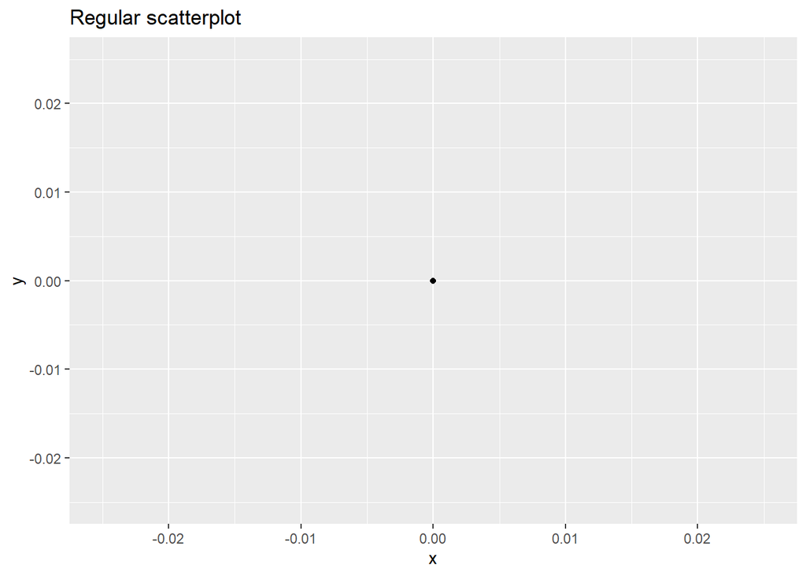

```r
ggplot(data = jitter_example, mapping = aes(x = x, y = y)) +
  geom_point() +
  coord_cartesian(xlim = c(-0.025, 0.025), ylim = c(-0.025, 0.025)) +
  labs(title = "Regular scatterplot")
```

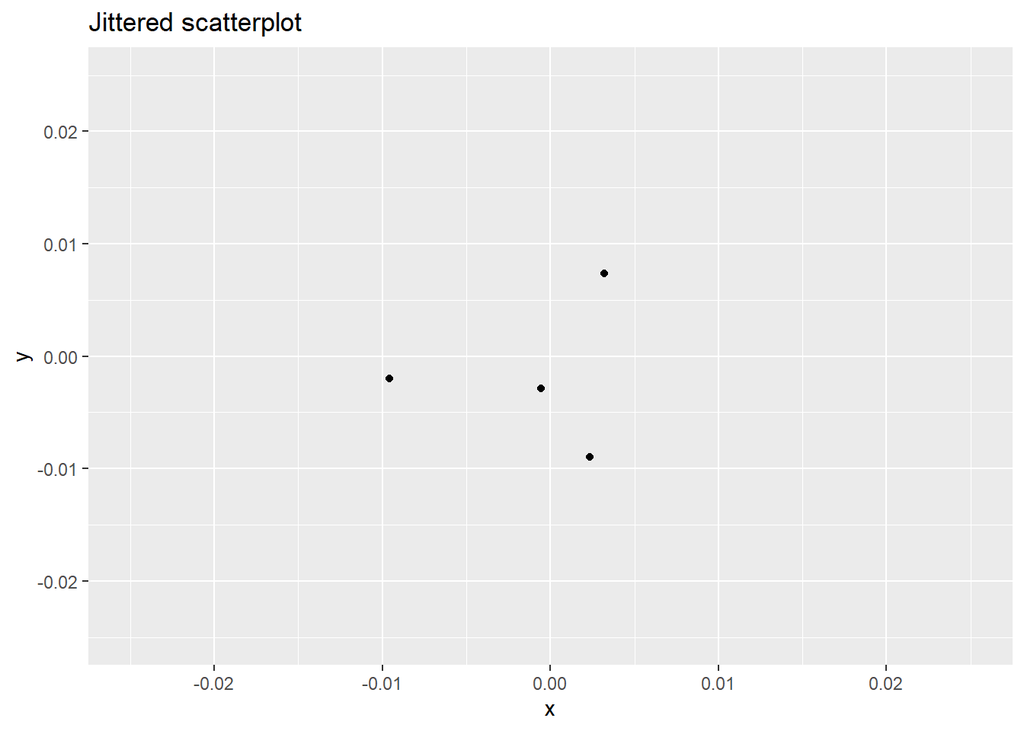

```r
ggplot(data = jitter_example, mapping = aes(x = x, y = y)) +
  geom_jitter(width = 0.01, height = 0.01) +
  coord_cartesian(xlim = c(-0.025, 0.025), ylim = c(-0.025, 0.025)) +
  labs(title = "Jittered scatterplot")
```

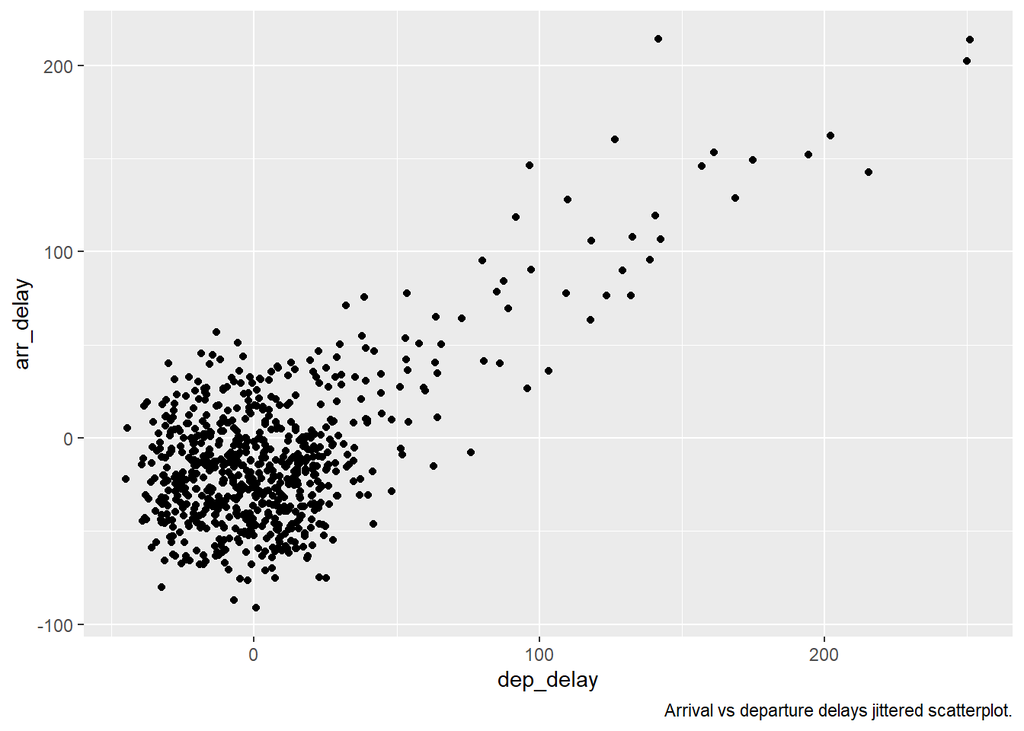

```r
ggplot(data = alaska_flights, mapping = aes(x = dep_delay, y = arr_delay)) +
  geom_jitter(width = 30, height = 30) +
  labs(caption="Arrival vs departure delays jittered scatterplot.")
```

## Scatterplot of our questionnaire data

First, let’s load our questionnaire data file using the read.csv function:

```r
q <- read.csv('https://raw.githubusercontent.com/umsi-data-science/si544-fa2020/master/544fa2019questionnaire.csv')
```

Now, let’s look at a plot of enthusiasm as a function of anxiety:

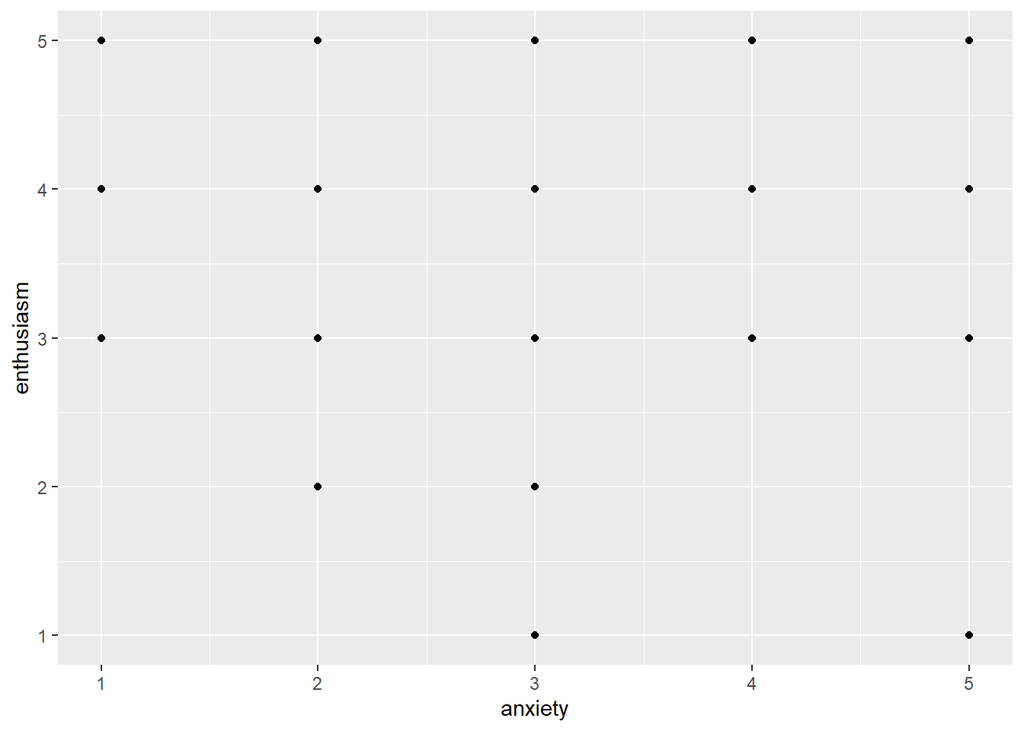

```r
ggplot(data=q, mapping=aes(x = anxiety, y=enthusiasm)) + geom_point()
```

Which of “alpha” and “jitter” do you think would be better?

Let’s try both:

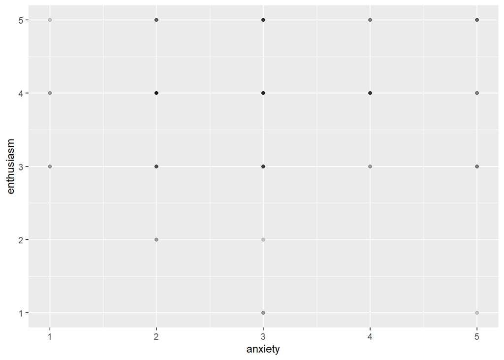

```r
ggplot(data=q, mapping= aes(x = anxiety, y=enthusiasm)) + geom_point(alpha=0.2)
```

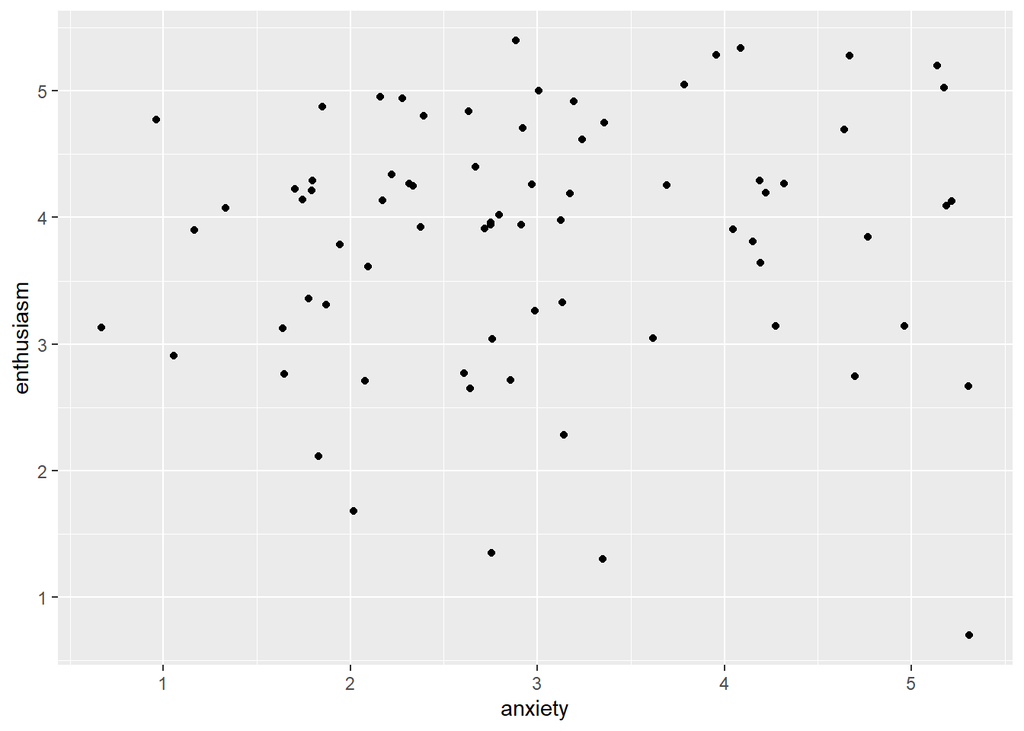

```r
ggplot(data=q, mapping= aes(x = anxiety, y=enthusiasm)) + geom_jitter()
```

## Learning Check (LC544.3.1)

Which of alpha and jitter gave the better results? Why?

INSERT YOUR ANSWER HERE I think alpha is better because jitter seems to misrepresent the data. Of course, if we tone the jitter down a bit it will probably provide better results. Ultimately, given the context, there’s probably strengths and weaknesses to both.

## Linegraphs

Let’s load and filter some data:

```r
early_january_weather <- weather %>%
  filter(origin == "EWR" & month == 1 & day <= 15)
```

## Learning Check (LC544.3.2)

What does the previous chunk do?

INSERT YOUR ANSWER HERE It creates a variable that filters weather data to only flights originating from Newark ‘EWR’ from the first half of January.

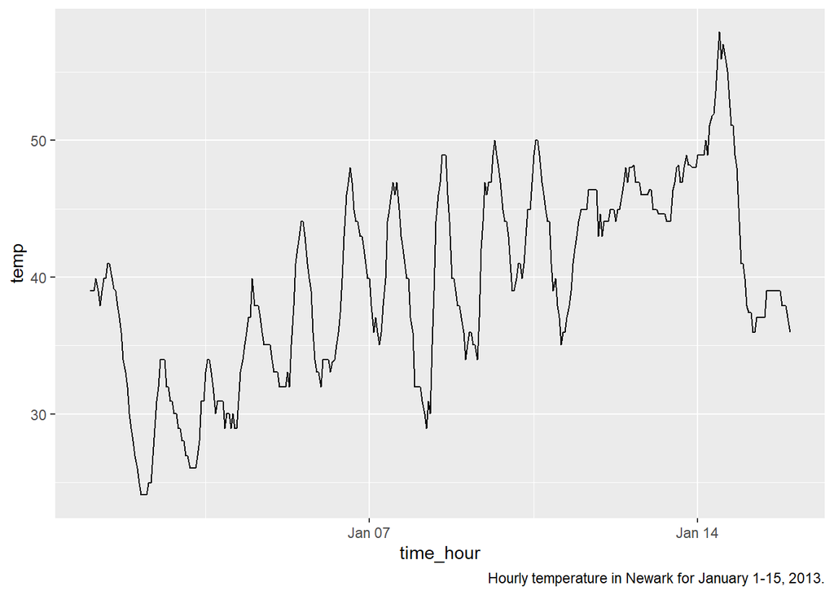

```r
ggplot(data = early_january_weather, mapping = aes(x = time_hour, y = temp)) +
  geom_line() +
  labs(caption="Hourly temperature in Newark for January 1-15, 2013.")
```

Now let’s do the same for our questionnaire data:

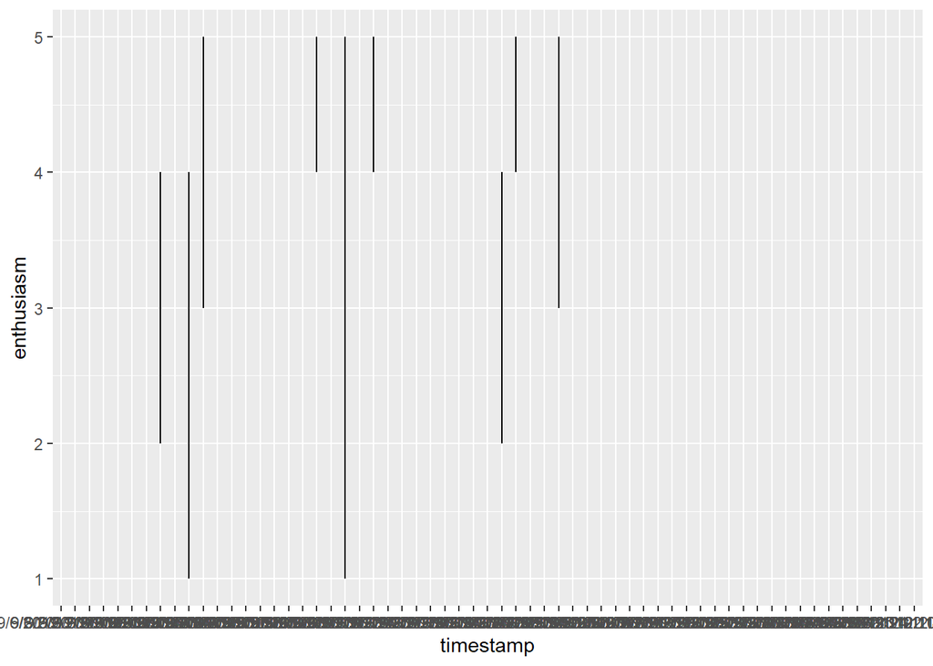

```r
ggplot(data=q, mapping=aes(x = timestamp, y=enthusiasm)) + geom_line()
```

Not really helpful, is it? Let’s convert the string values of dates to something a bit more numeric using POSIXct (POSIX calendar time; POSIX can be thought of as a “flavor” of Unix):

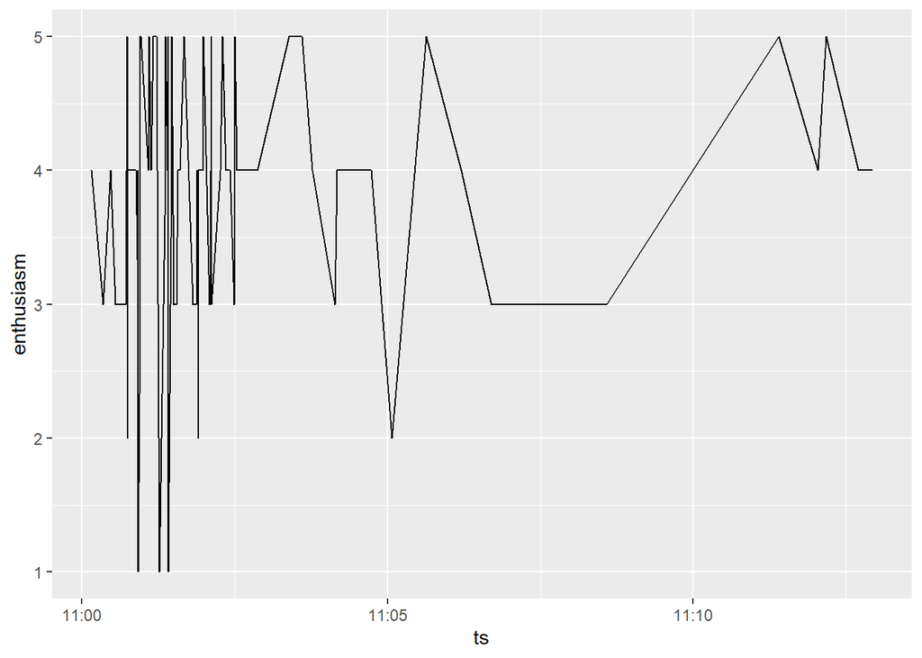

```r
q$ts = as.POSIXct(q$timestamp, format="%m/%d/%Y %H:%M:%S")
ggplot(data=q, mapping=aes(x = ts, y=enthusiasm)) + geom_line()
```

## Learning Check (LC544.3.3) What can you say about the expression of enthusiasm during the time the questionnaire was administered?

INSERT YOUR ANSWER HERE. It appears to have a greater variation spread between greater and lesser degrees of enthusiasm

## Histograms

NOTE: You might want to use the console to View(weather)

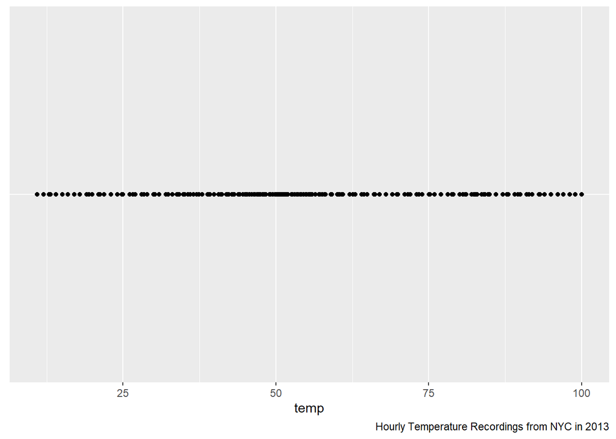

```r
ggplot(data = weather, mapping = aes(x = temp, y = factor("A"))) +
  geom_point() +
  theme(axis.ticks.y = element_blank(),
        axis.title.y = element_blank(),
        axis.text.y = element_blank()) +
  labs(caption = "Hourly Temperature Recordings from NYC in 2013")
```

Let’s “raise” the vertical dimension according to the counts of things in bins:

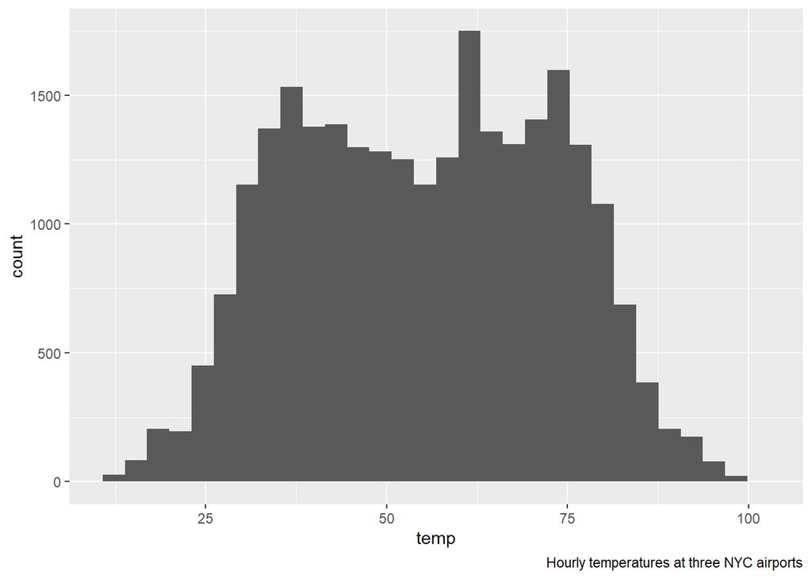

```r
## ----weather-histogram, warning=TRUE, fig.cap="Histogram of hourly temperatures at three NYC airports."----
ggplot(data = weather, mapping = aes(x = temp)) +
  geom_histogram() +
  labs(caption = "Hourly temperatures at three NYC airports")
```

Make things a bit clearer:

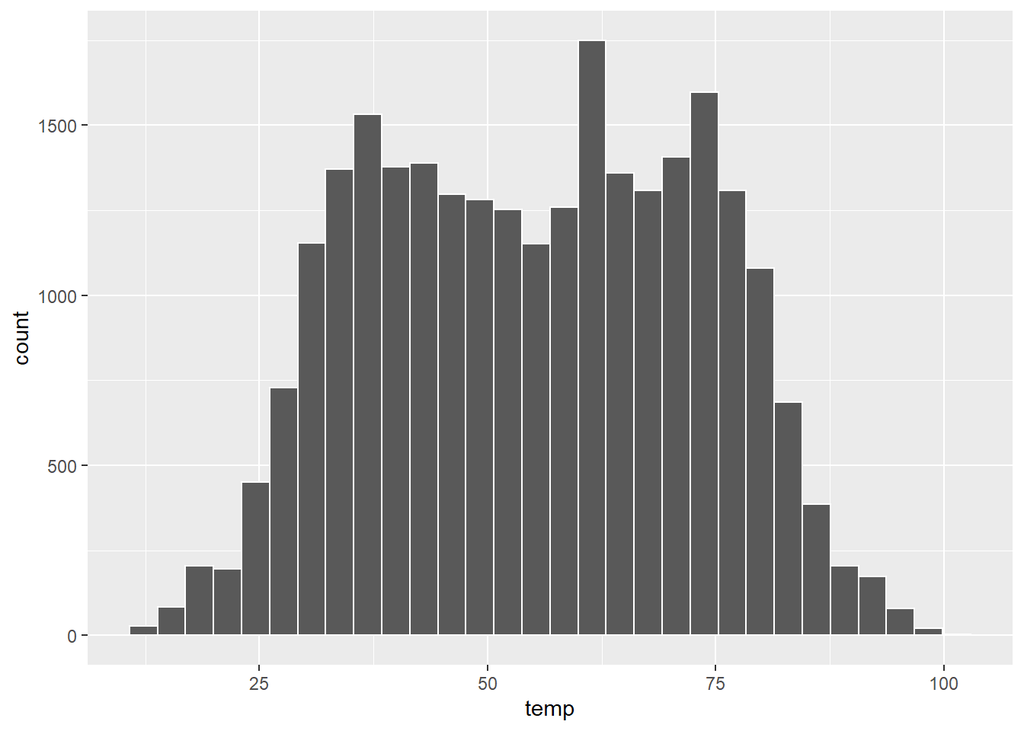

```r
ggplot(data = weather, mapping = aes(x = temp)) +
  geom_histogram(color = "white")
```

And perhaps a bit prettier:

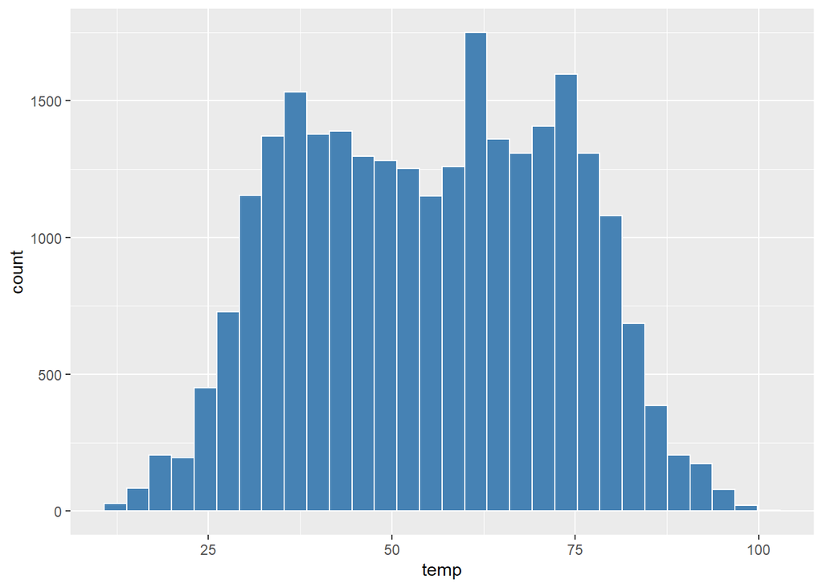

```r
ggplot(data = weather, mapping = aes(x = temp)) +
  geom_histogram(color = "white", fill = "steelblue")
```

Let’s see what happens if we change the number of bins:

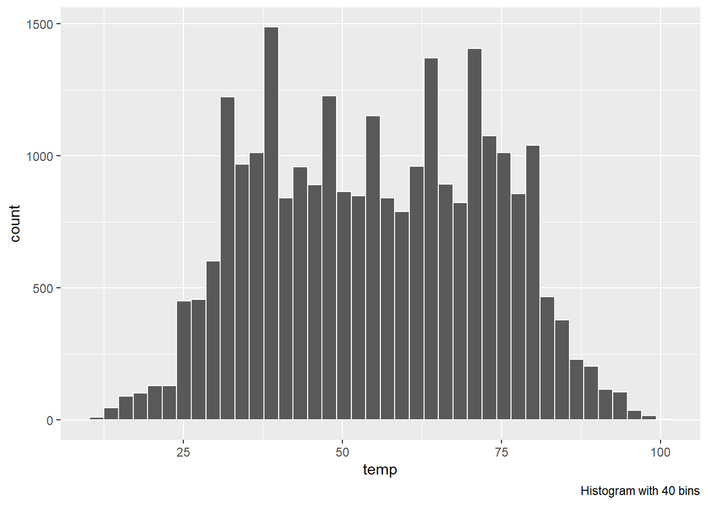

```r
ggplot(data = weather, mapping = aes(x = temp)) +
  geom_histogram(bins = 40, color = "white") +
  labs(caption="Histogram with 40 bins")
```

Instead of specifying the number of bins, we can specify the width of each bin:

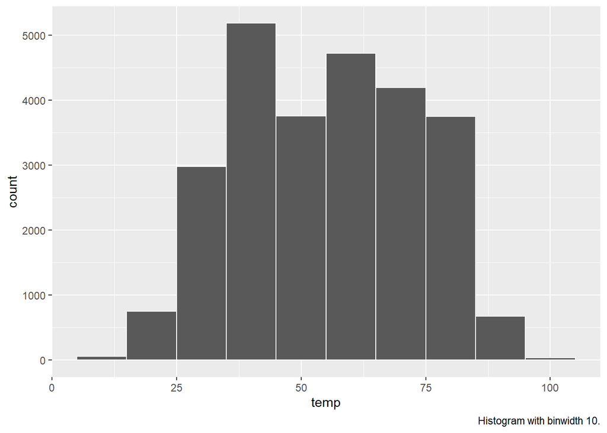

```r
ggplot(data = weather, mapping = aes(x = temp)) +
  geom_histogram(binwidth = 10, color = "white") +
  labs(caption="Histogram with binwidth 10.")
```

## Learning Check (LC3.16) What would you guess is the “center” value in this distribution? Why did you make that choice?

INSERT YOUR ANSWER HERE I’m guessing 57. I think the peak around 35 pulls the distribution closer to 50.

## Faceting

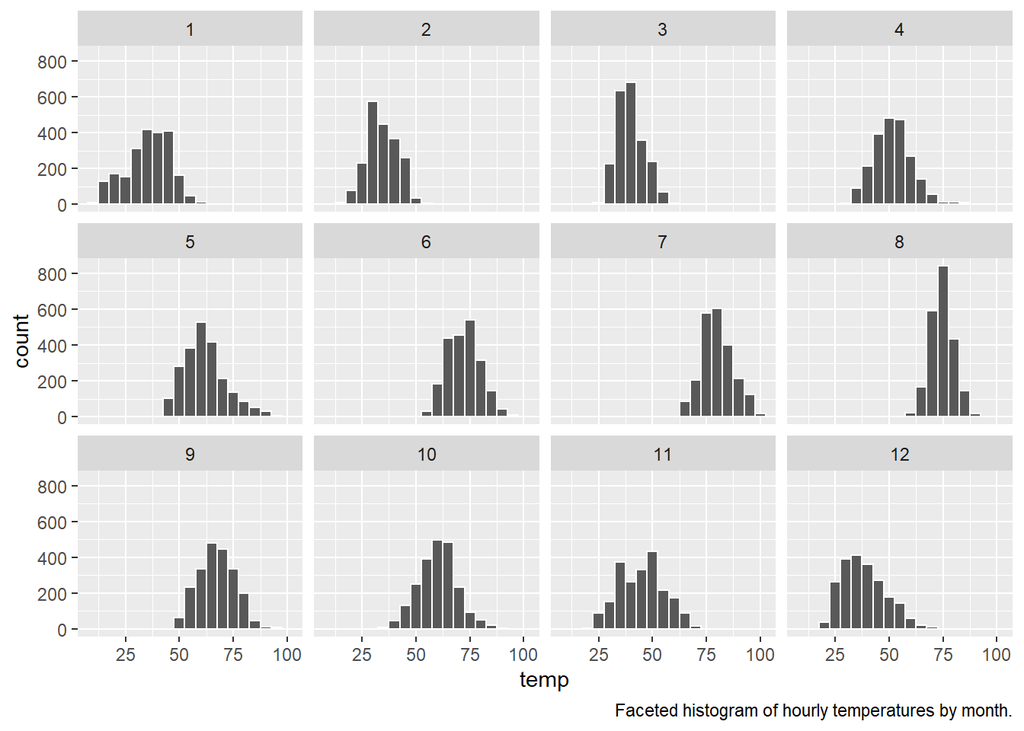

```r
ggplot(data = weather, mapping = aes(x = temp)) +
  geom_histogram(binwidth = 5, color = "white") +
  facet_wrap(~ month) +
  labs(caption="Faceted histogram of hourly temperatures by month.")
```

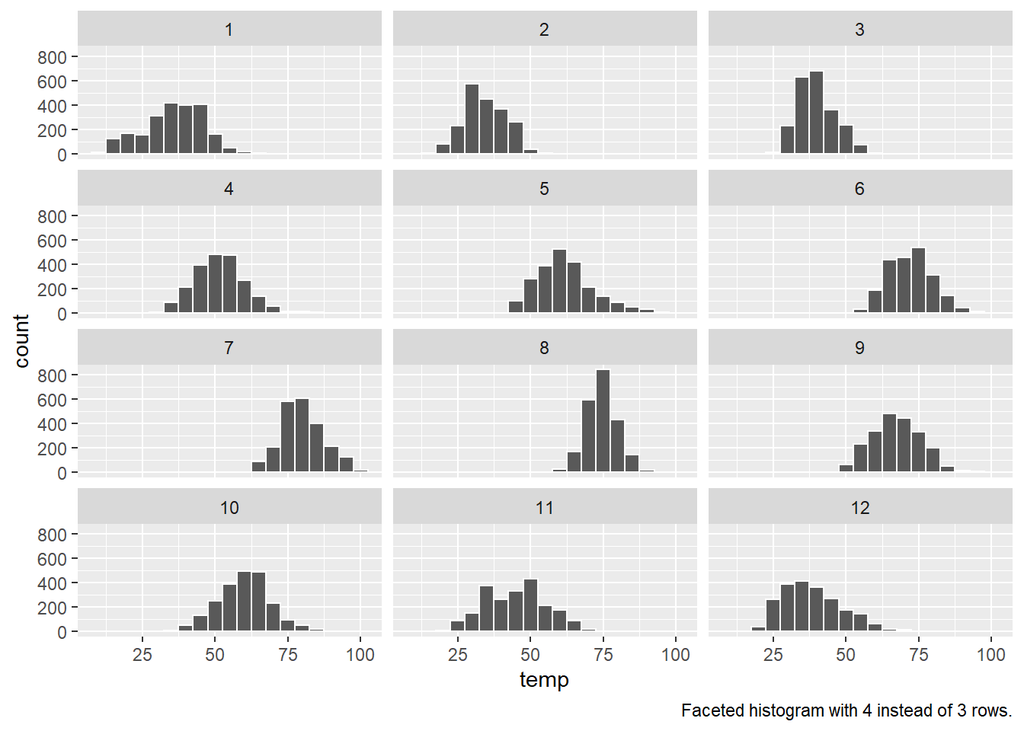

```r
## ----facethistogram2, fig.cap="Faceted histogram with 4 instead of 3 rows."----
ggplot(data = weather, mapping = aes(x = temp)) +
  geom_histogram(binwidth = 5, color = "white") +
  facet_wrap(~ month, nrow = 4) +
  labs(caption="Faceted histogram with 4 instead of 3 rows.")
```

## Boxplots

Let’s start with a bit of a problem:

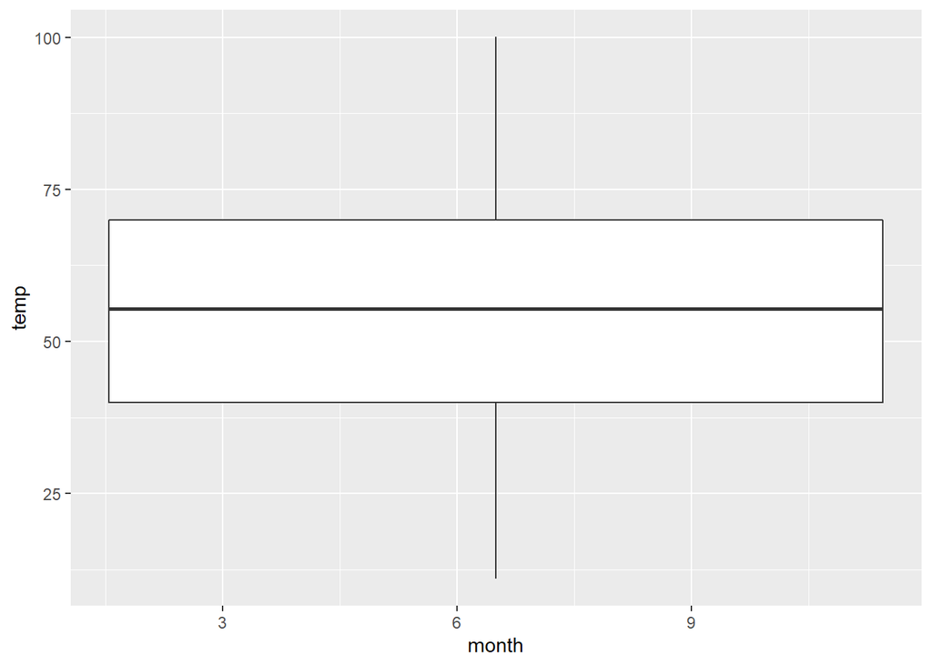

```r
ggplot(data = weather, mapping = aes(x = month, y = temp)) +
  geom_boxplot()
```

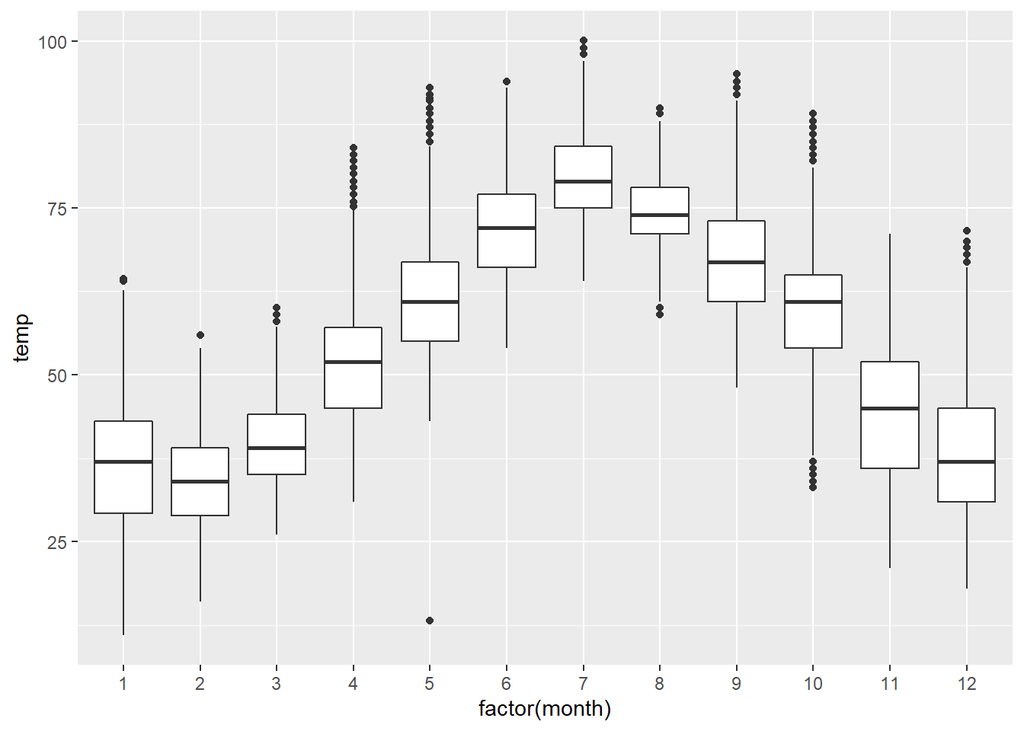

```r
ggplot(data = weather, mapping = aes(x = factor(month), y = temp)) +
  geom_boxplot()
```

## Barplots

Two types of data: pre-counted vs. not pre-counted. See the following tibbles for an example:

```r
fruits <- tibble(
  fruit = c("apple", "apple", "orange", "apple", "orange")
)
fruits_counted <- tibble(
  fruit = c("apple", "orange"),
  number = c(3, 2)
)
```

```r
fruits
```

```
## # A tibble: 5 x 1
##   fruit
##   <chr>
## 1 apple
## 2 apple
## 3 orange
## 4 apple
## 5 orange
```

```r
fruits_counted
```

```
## # A tibble: 2 x 2
##   fruit  number
##   <chr>   <dbl>
## 1 apple       3
## 2 orange      2
```

Use geom_bar when elements are not pre-counted:

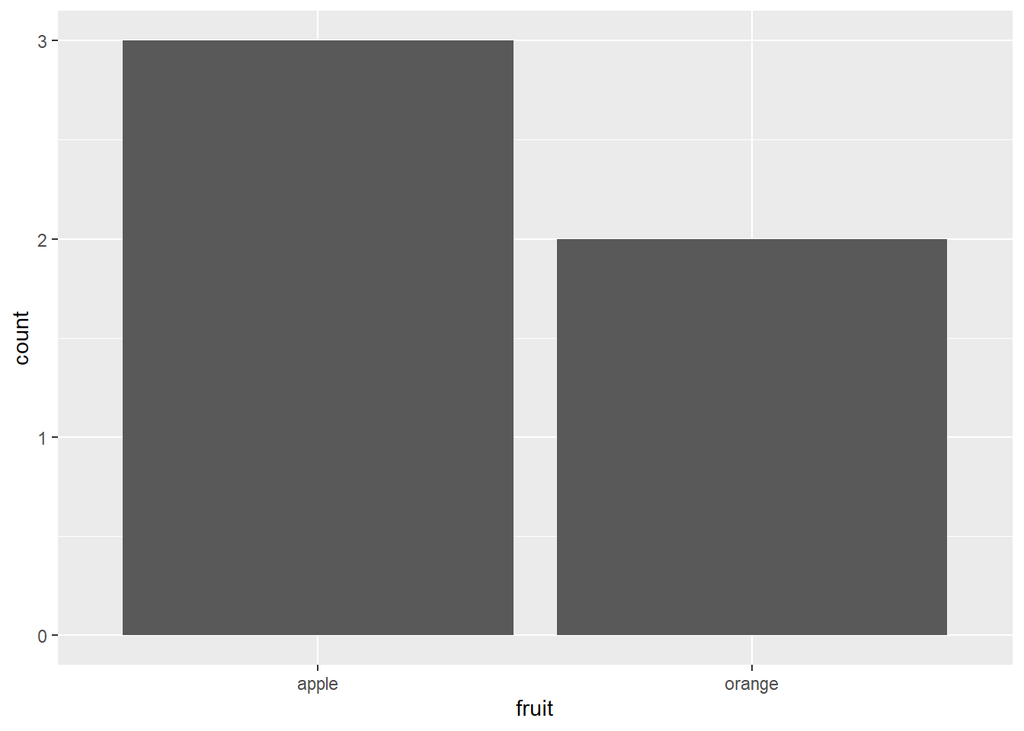

```r
## ----geombar, fig.cap="Barplot when counts are not pre-counted.", fig.height=2.5----
ggplot(data = fruits, mapping = aes(x = fruit)) +
  geom_bar() +
  labs("Barplot when counts are not pre-counted.")
```

Use geom_col() when counts are pre-counted:

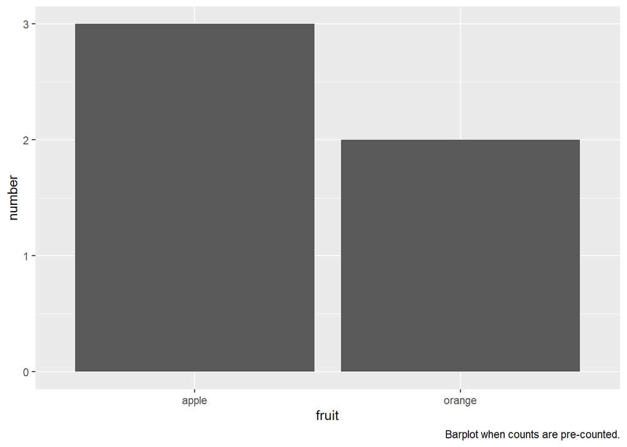

```r
ggplot(data = fruits_counted, mapping = aes(x = fruit, y = number)) +
  geom_col() +
  labs(caption="Barplot when counts are pre-counted.")
```

Let’s take a look at our flights data:

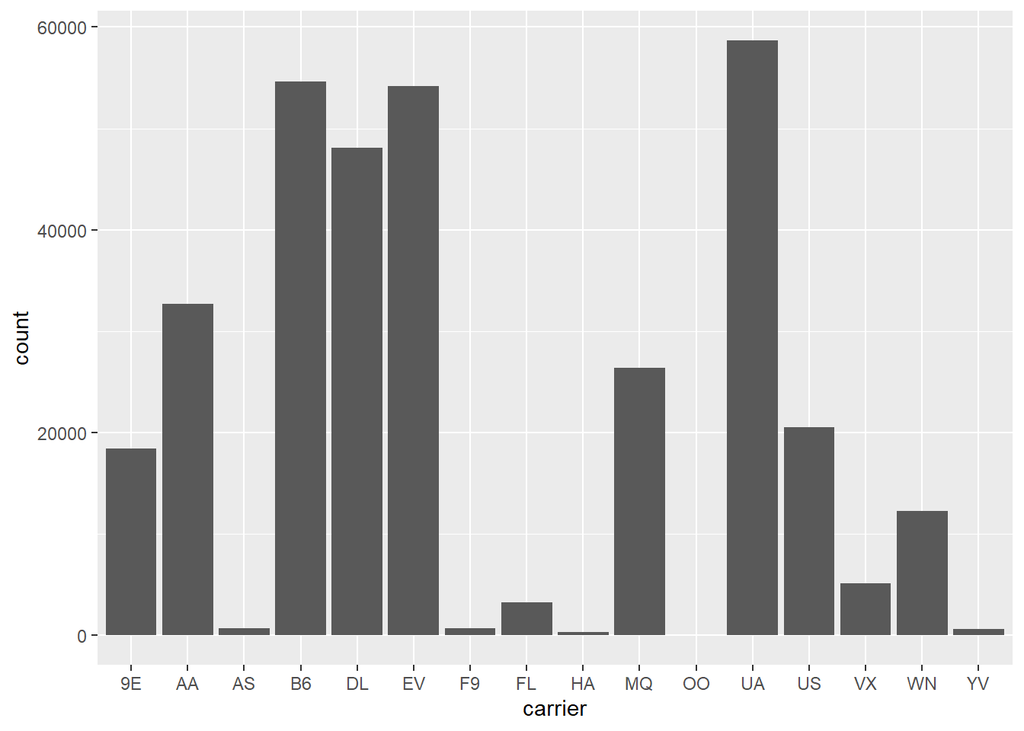

```r
ggplot(data = flights, mapping = aes(x = carrier)) +
  geom_bar()
```

```r
flights_table <- flights %>%
  group_by(carrier) %>%
  summarize(number = n())
```

Take a look at flights_table, the run the following chunk:

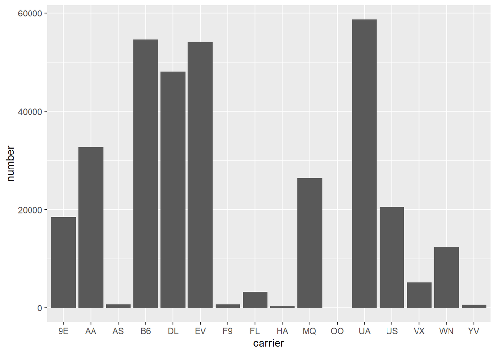

```r
ggplot(data=flights_table, mapping = aes(x=carrier, y=number)) + geom_col()
```

## Learning Check (LC544.3) Run the following code to create a bar chart for the grades from our survey. Explain how the second chart differs from the first.

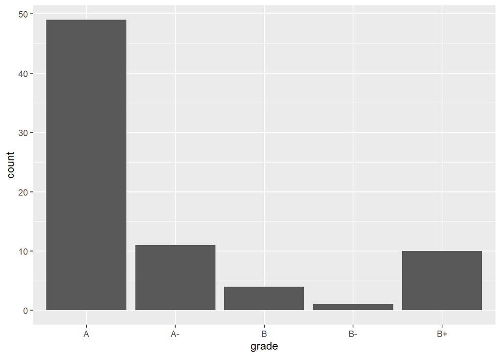

```r
ggplot(data=q, mapping = aes(x=grade)) +
  geom_bar()
```

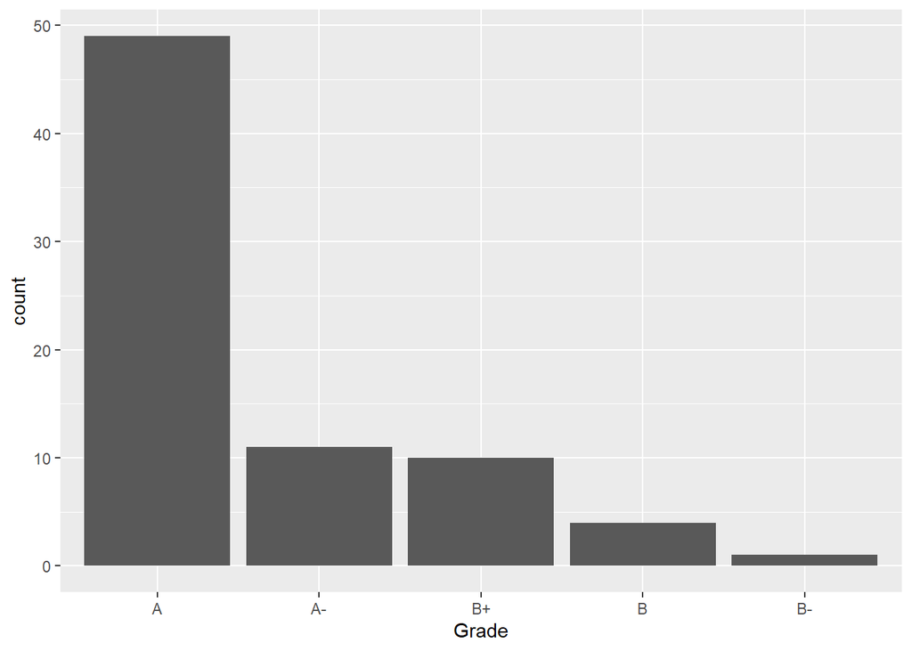

```r
ggplot(data=q, mapping = aes(x=factor(grade, levels=c('A','A-','B+','B','B-')))) +
  geom_bar() +
  labs(x="Grade")
```

## A word about pie charts

DON’T!

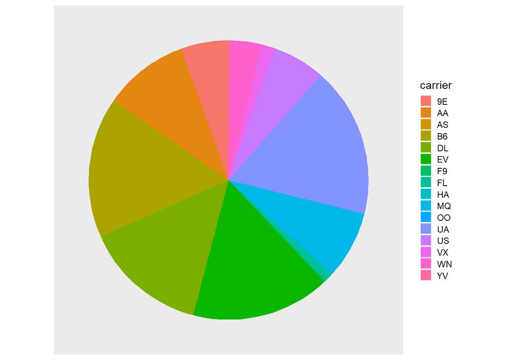

```r
ggplot(flights, mapping = aes(x = factor(1), fill = carrier)) +
  geom_bar(width = 1) +
  coord_polar(theta = "y") +
  theme(axis.title.x = element_blank(),
    axis.title.y = element_blank(),
    axis.ticks = element_blank(),
    axis.text.y = element_blank(),
    axis.text.x = element_blank(),
    panel.grid.major = element_blank(),
    panel.grid.minor = element_blank()) +
  guides(fill = guide_legend(keywidth = 0.8, keyheight = 0.8))
```

There are better ways to handle these data; typically using barplots.

## Barplots for 2

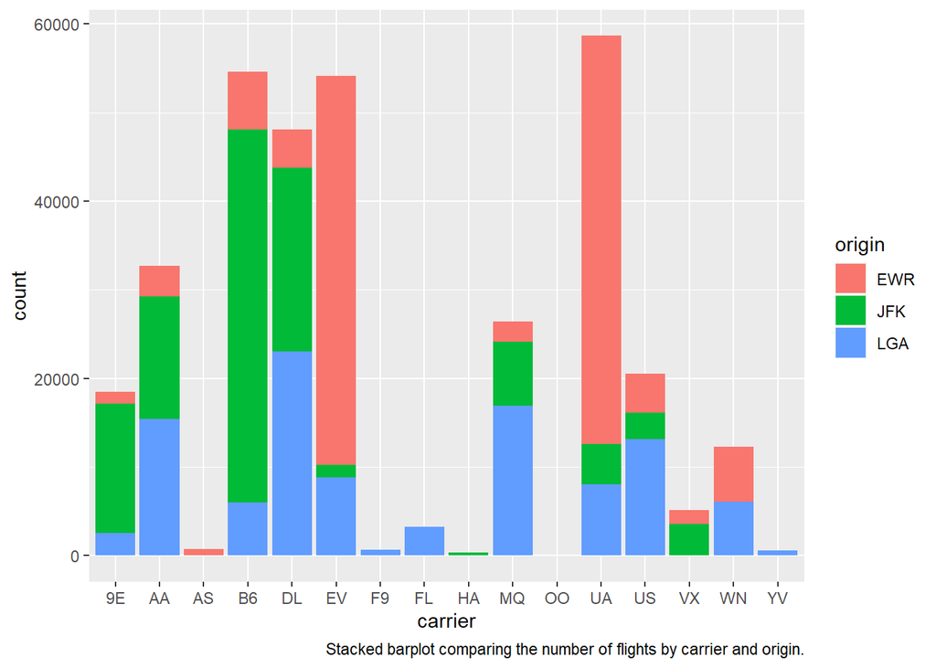

```r
ggplot(data = flights, mapping = aes(x = carrier, fill = origin)) +
  geom_bar() +
  labs(caption="Stacked barplot comparing the number of flights by carrier and origin.")
```

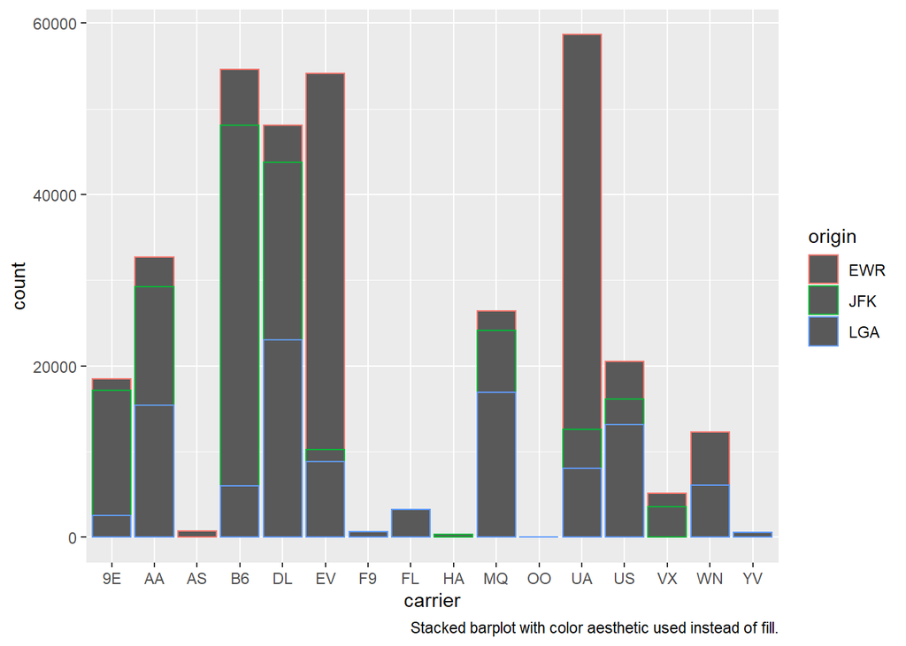

```r
ggplot(data = flights, mapping = aes(x = carrier, color = origin)) +
  geom_bar() +
  labs(caption="Stacked barplot with color aesthetic used instead of fill.")
```

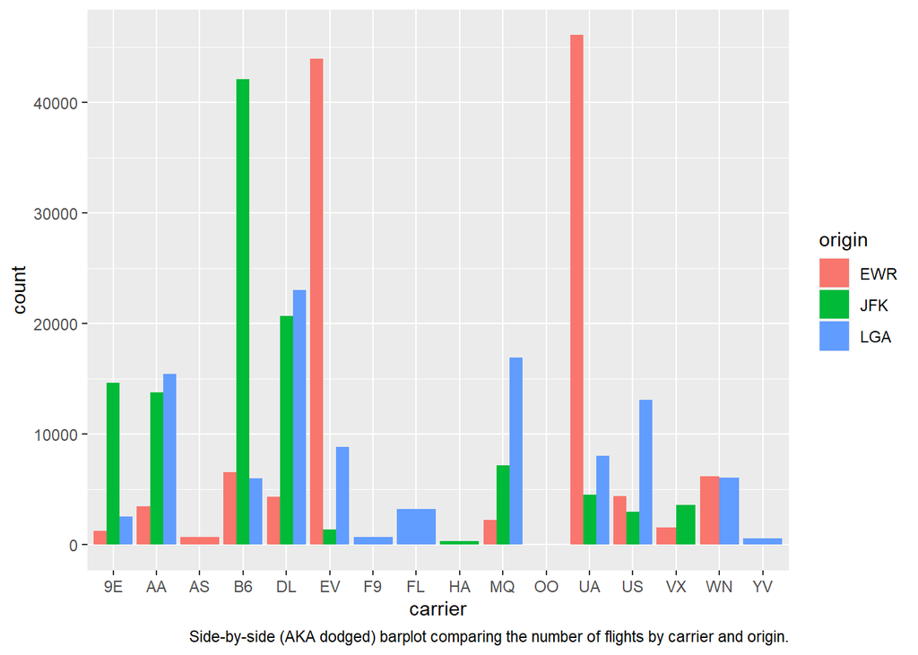

```r
ggplot(data = flights, mapping = aes(x = carrier, fill = origin)) +
  geom_bar(position = "dodge") +
  labs(caption="Side-by-side (AKA dodged) barplot comparing the number of flights by carrier and origin.")
```

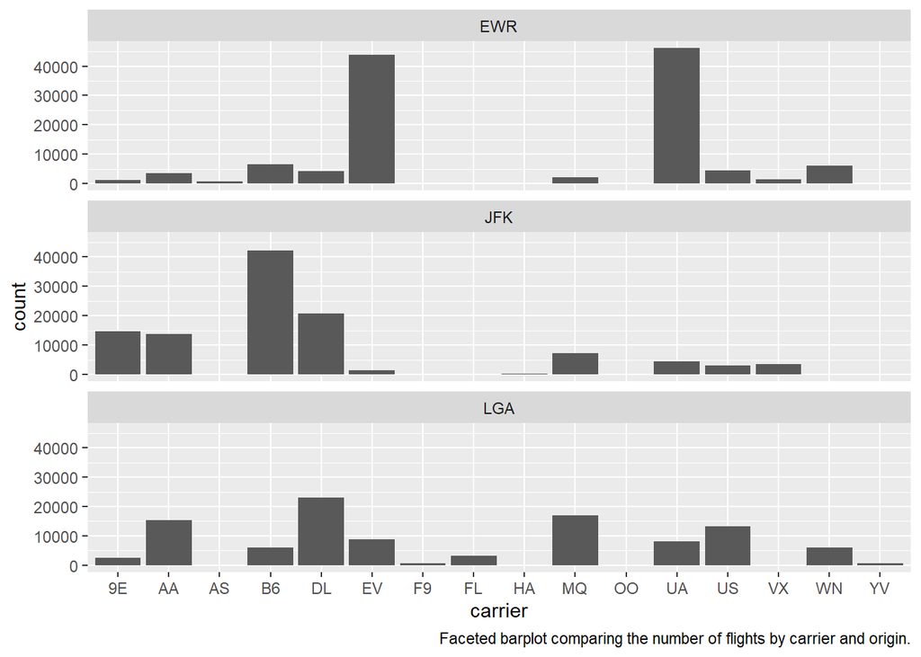

```r
ggplot(data = flights, mapping = aes(x = carrier)) +
  geom_bar() +
  facet_wrap(~ origin, ncol = 1) +
  labs(caption="Faceted barplot comparing the number of flights by carrier and origin.")
```

## Learning Check (LC3.31) Why do you think people continue to use pie charts?

END OF NOTEBOOK!

Please remember to Knit this notebook into HTML and submit the HTML version via Canvas.